```
title: "LEO Stats"
author: "Barry von Tobel"
date: "1/18/2021"
output:
  html_document:
  toc: true
  toc_float: true
  toc_collapsed: true
number_sections: true
toc_depth: 3
theme: lumen

#bibliography: references.bib
```

# Intro - Data dated 07Jan21

This analysis downloads from space-track the latest gp and cdm file sets using manually changed file date, which for this document is 07Jan21. This document is produced using the RMarkdown syntax that comes bundled with RStudio, an open-source R Integrated Development Environment. The R code for the analysis is embedded in the document, but the ‘ECHO’ is set to false so the code and code comments are not displayed on the page. A nice feature of RMarkdown and most other types of Web document tools is that the pagination isn’t enforced, so the document becomes one continuous page, a nice feature when the document has images, graphs, and tables. An future enhanced document can have the index of the heading on the left, which aids in navigation.

# LEO Statistics

The first graph depicts all the cataloged items in the space-track download. It is factored into the 4 catagories used by space.track.

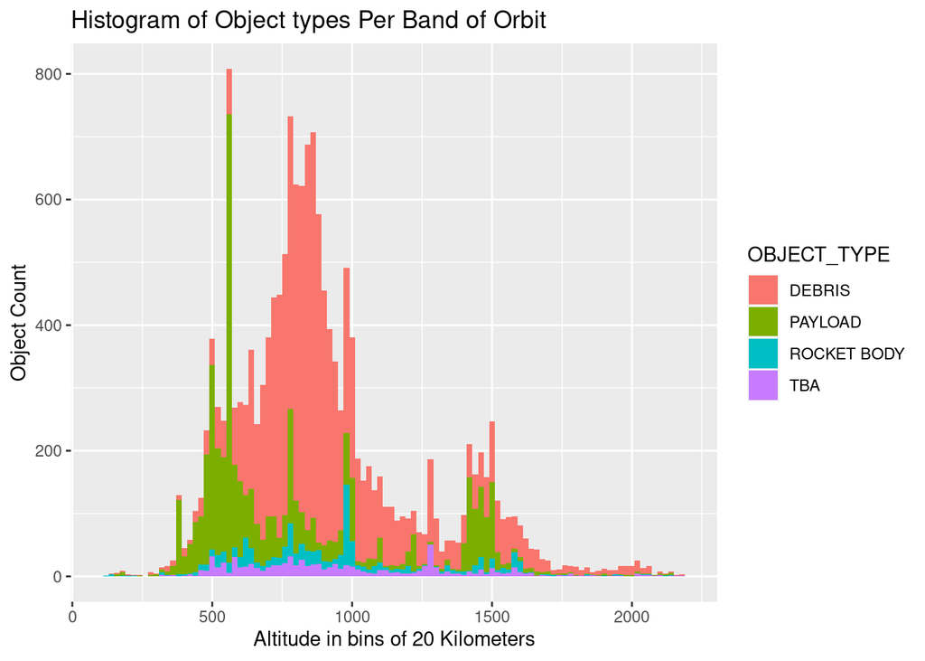

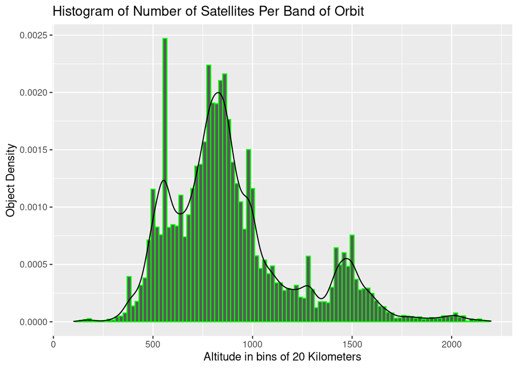

[output not shown]

[output cut: 16341 more lines]

# Density

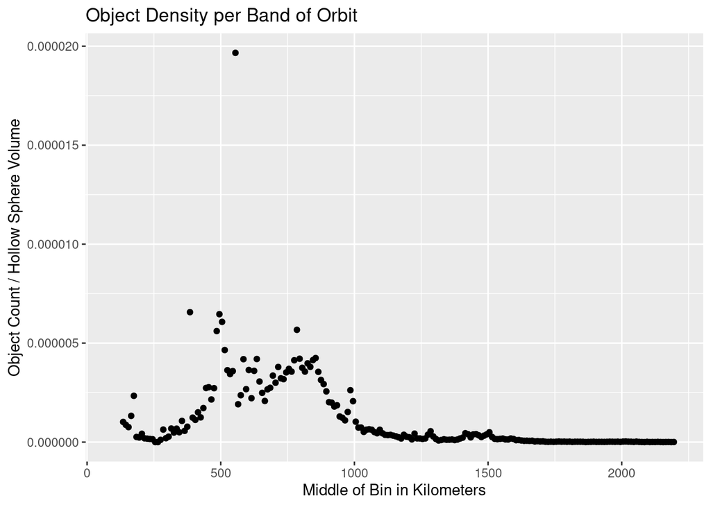

# Probability

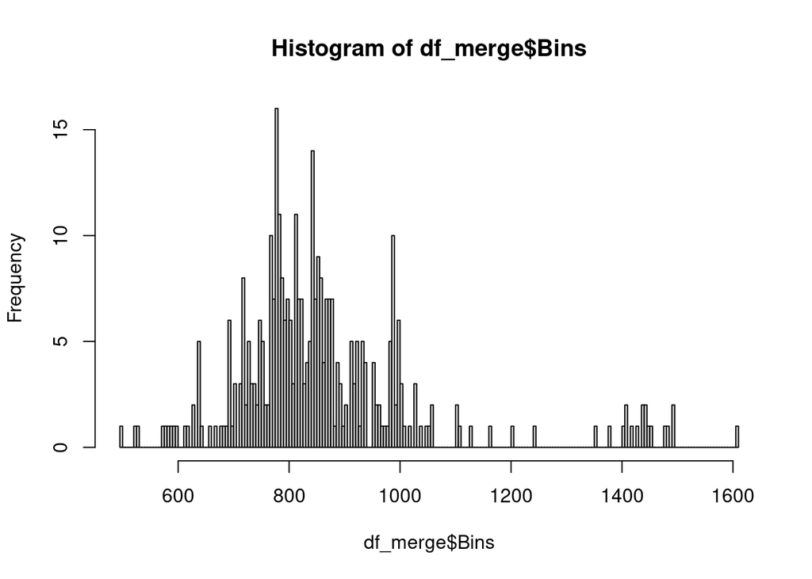

[figure not shown]

# test area